# R Notebook

Venus van Hoof

In this script, the environmental data is combined, scaled and tested for collinearity.

***Combine environmental data**

Measurements of chlorophyll-a, temperature, NO3, NO2, NH4 and PO4 were taken. These measurements are stored in two different CSV files. Because multiple measurements of each environmental variable were taken at each sampling location, the mean value at each sampling location is calculated. Because no measurements for chlorophyll-a and temperature were taken for the sampling site MERBAY, the mean was taken of the values from the locations MERBAY1 and MERBAY2. The values of NO3, NO2 and NH4 were summed to get the total dissolved inorganic nitrgoen (DIN). Afterwards, all environmenal data is combined to create one dataframe.

```r
setwd("C:/Users/Venus/OneDrive/Documents/Github/RajaAmpat_forams")

library(tidyverse)

###----------------calculate mean chlor-a & temperature data ------------------------------
envir1 <- read.csv("Rdata/envir.csv")
str(envir1)
```

```
'data.frame':   17034 obs. of  21 variables:
 $ date           : chr  "14/04/2023" "14/04/2023" "14/04/2023" "14/04/2023" ...
 $ time           : chr  "09:11.0" "09:12.2" "09:12.4" "09:12.7" ...
 $ depth          : num  0.105 0.205 0.311 0.403 0.499 ...
 $ pressure       : num  0.105 0.206 0.313 0.405 0.502 ...
 $ Temperature.CTD: num  33.2 33.2 33.2 33.2 33.2 ...
 $ Conductivity   : num  39.3 39.3 39.3 39.3 39.3 ...
 $ Salinity       : num  21.1 21.1 21.1 21.1 21.1 ...
 $ Sound.Velocity : num  1538 1538 1538 1538 1538 ...
 $ Density        : num  1010 1010 1010 1010 1010 ...
 $ Chl.a          : num  77.827 2.232 7.046 0.517 1.048 ...
 $ lat.CTD        : num  -0.588 -0.588 -0.588 -0.588 -0.588 ...
 $ lon.CTD        : num  131 131 131 131 131 ...
 $ region         : chr  "Dampier" "Dampier" "Dampier" "Dampier" ...
 $ island         : chr  "Mansuar" "Mansuar" "Mansuar" "Mansuar" ...
 $ site_type      : chr  "lake" "lake" "lake" "lake" ...
 $ site           : chr  "RAJ04" "RAJ04" "RAJ04" "RAJ04" ...
 $ lat.GPS        : num  -0.59 -0.59 -0.59 -0.59 -0.59 ...
 $ lon.GPS        : num  131 131 131 131 131 ...
 $ data_set       : chr  "yes" "yes" "yes" "yes" ...
 $ dist.people    : num  0.00195 0.00195 0.00195 0.00195 0.00195 ...
 $ connection     : num  0.07 0.07 0.07 0.07 0.07 0.07 0.07 0.07 0.07 0.07 ...
```

```r
#calculate mean chlor-a (filter out measurements shallower than 1m)
envir1 %>%
  filter(depth >= 1) %>%
  group_by(site, site_type) %>%
  summarise(mean_chlora = mean(Chl.a), .groups = "drop")-> chlor_a

#calculate mean temperature
envir1 %>%
  group_by(site, site_type) %>%
  summarise(mean_temp = mean(Temperature.CTD), .groups = "drop")-> temp

#combine chlor-a and temp data
chlor_a %>%
  left_join(temp, by = c("site", "site_type")) -> envir_var1

#add row for Mer-bay
envir_var1 %>%
  filter(site %in% c("MER_Bay1","MER_Bay2")) %>%
  summarise(
    across(where(is.numeric), \(x) mean(x, na.rm = TRUE)),
    site_type = first(site_type)) %>%
  mutate(site = "MERBay") -> Merbay

#add row to envir var
envir_var1  %>%
  bind_rows(Merbay)-> envir_var1

###------------------calculate mean DIN data---------------------------
din <- read.csv("Rdata/DIN.csv")

din %>%
  group_by(site) %>%
  mutate(across(tail(names(.), 5), ~mean(.x, na.rm = TRUE))) -> din2

din2 %>%
  group_by(site, region, site_type) %>%
  summarise(across(where(is.numeric), ~mean(.x, na.rm = TRUE)),
            .groups = "drop") -> din3

din3 %>%
  group_by(site, region, site_type)%>%
  mutate(DIN = sum(NH4,NO2,NO3)) %>%
  dplyr::select(-NH4, -NO3.NO2,-NO2,-NO3)-> din4

#----------------calculate PO4:DIN ratio -----------------------------------

din4 %>%
  mutate(DINIDIP = DIN/PO4) -> envir_ratio

###------------------combine DIN and chlor-a data----------------------
din4 %>%
  full_join(envir_var1, by = c("site", "site_type")) %>%
  drop_na()-> envir_var2

envir_var2 %>%
  rename(Location = site) %>%
  rename(Habitat = site_type) -> envir_var2

write.csv(envir_var2, "Rdata/environmental_dataNEW.csv")

#remove locations that do not have foram data
envir_var2 %>%
  filter( !Location %in% c("HarapanJaya", "Kajerepop", "MERWorkshop", "MIS01", "RAJ04",
                           "mangrove", "MIS14", "MIS17", "MIS20", "MIS31", "MIS40", "MIS40-Lagoon",
                           "RAJ13", "UsahaJaya", "WAR03", "Batbitieru_NW",
                           "Batbitieru_NW2", "Batbitieru_SWPoint", "Batbitieru_SWPoint2",
                           "Lalelkai", "LosReef", "MER_Pier", "Reef-MIS01", "Reef-MIS06",
                           "Reef-MIS27", "YamniniHomestay", "MER_Pier2", "Yellu")) -> filt_envir
```

**Scaling environmental variables**

All environmental variables are scaled and checked for normality. Because the distribution of most environmental variables was not normal, the spearman rank correlation test was used for pairwise comparison. The results are visualized in a correlation matrix from the corrplot package. PO4 and DIN were collinear, therefore PO4 was removed.

```r
setwd("C:/Users/Venus/OneDrive/Documents/Github/RajaAmpat_forams")
#scale envir variables
filt_envir %>%
  ungroup() %>%
  mutate(across(c(PO4, DIN, mean_chlora, mean_temp),
                ~ as.numeric(scale(.)))) -> envir_sc
#check for normality
shapiro.test(envir_sc$PO4) #pval = 0.0006454 -> not normal
```

```
    Shapiro-Wilk normality test

data:  envir_sc$PO4
W = 0.79953, p-value = 0.0006454
```

```r
shapiro.test(envir_sc$DIN) #pval =  0.02259 -> not normal
```

```
    Shapiro-Wilk normality test

data:  envir_sc$DIN
W = 0.8901, p-value = 0.02259
```

```r
shapiro.test(envir_sc$mean_chlora) #pval = 0.001652-> not normal
```

```
    Shapiro-Wilk normality test

data:  envir_sc$mean_chlora
W = 0.82547, p-value = 0.001652
```

```r
shapiro.test(envir_sc$mean_temp) #pval =  0.8878 -> normal
```

```
    Shapiro-Wilk normality test

data:  envir_sc$mean_temp
W = 0.97762, p-value = 0.8878
```

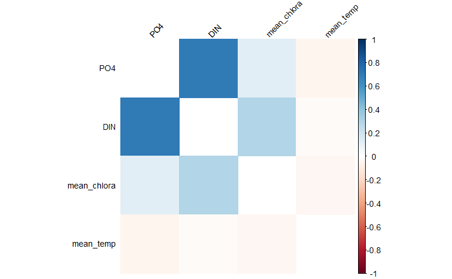

```r
library(corrplot)
#calculate correlation matrix
envir_sc %>%
  dplyr::select(PO4, DIN, mean_chlora, mean_temp) %>%
  cor(method ="spearman", use = "pairwise.complete.obs") -> cor_matrix #or use spearman rank test for non normal

#make plot
corrplot(cor_matrix, method = "color",
         tl.cex = 0.8,
         tl.srt = 45,
         tl.col = "black",
         diag = FALSE)
```

```r
diag(cor_matrix) <- 0
collinear_var <- which(abs(cor_matrix) > 0.7 & abs(cor_matrix) < 1, arr.ind = TRUE) #select correlations that are higher than 0.7 but not higher than 1
high_cor_pairs <- data.frame(
  Var1 = rownames(cor_matrix)[collinear_var[,1]],
  Var2 = colnames(cor_matrix)[collinear_var[,2]],
  Correlation = cor_matrix[collinear_var]) #DIN & PO4 are collinear

#remove collinear variables (PO4)
env_clean <- envir_sc %>% dplyr::select(-PO4)

write.csv(env_clean, "Rdata/clean_envir_datanew.csv")
```